# STATS202 Homework #1

Chenbo Wang

9/16/2020

## 1. Exercise 1 from section 2.4

### Part (a)

In the case where n is much larger than p, I expect flexible learning method to perform **better** than inflexible ones. When p (number of predictors) is small, the variance of the model would be small regardless of flexibility, and because bias decreases as flexibility increases, we should recommend flexible method that results in small variance + squared bias.

### Part (b)

When p is much larger than n, I expect flexible learning method to perform **worse** than inflexible ones, because with so few samples to fit a model, overfitting is very likely to be the concern if we increase flexibility.

### Part (c)

When the relationship is highly nonlinear, flexible method performs **better**, as high flexibility allows the fitted model to better capture the nonlinearity of the “true” relationship. Low flexibility incurs in linear model that doesn’t capture nonlinearity.

### Part(d)

When variance of the error is high, flexible method would perform **worse**, because with high noises in the trainning samples, flexible method would try so hard to fit the noise and end up overfitting (greatly increase variance even though it does decrease bias).

## 2. Exercise 2 from section 2.4

### Part (a)

This is a **regression** problem because the output variable (CEO salary) of this supervised learning is quantitative.  
We are interested in **inference** more than prediction because we are trying to understand which variables influence the output (CEO salary) rather than trying to predict.  
sample size **n = 500** (top 500 firms in the US), number of predictors **p = 3** (profit, number of employees, industry)

### Part(b)

This is a **classification** problem because the output variable (success or failure) is qualitative.  
We are interested in **prediction** as we are analyzing the data samples of similar products in hope of predicting the fate of the new product.  
sample size **n = 20** (data of 20 other similar previously-launched products), number of predictors **p = 13** (price charged for the product, marketing budget, competition price, and ten other variables.)

### Part(c)

This is a **regression** problem because the output variable (% change in the USD/Euro) is quantitative.  
We are interested in **prediction** as we are attempting to find a relationship between the USD/Euro exchange rate and the weekly changes in the world stock markets.  
sample size **n = 52** (52 weeks per year), number of predictors **p = 3** (the % change in the US market, the % change in the British market, and the % change in the German market.)

## 3. Exercise 3 from section 2.4

### Part(a)

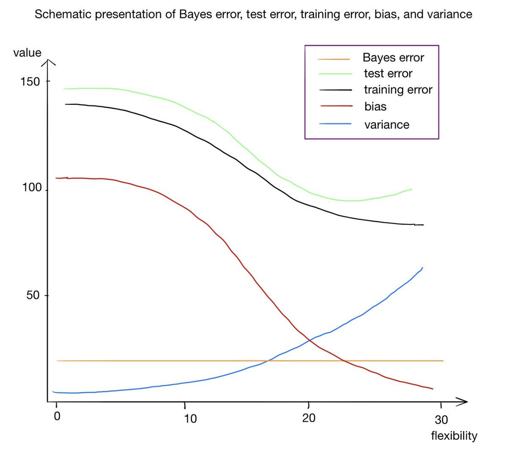

Schematic presentation of Bayes error, test error, training error, bias, and variance

### Part(b)

**Bayes error**: it represents how much of the response is not predictable by any method, therefore it remains constant regardless of flexibility. defines the lower limit, the test error is bounded  
**variance**: it increases as flexibility increases.  
**bias**: it decreases as flexibility increases and the model fits the samples closer.  
**training error**: it monotonically decreases as flexibility increases, because an overfit model (very high flexibility) produce very low MSE for trainning samples.  
**test error**: it shows a concave curve because test error equals bias + variance + irreducible error, and bias decreases, variance increases, and irreducible error remains constant as flexibility increases, leading to a U-shaped curve.

## 4. Exercise 7 from section 2.4

### Part(a)

```r
#load libraries
library(tidyverse)
# create vectors for six observations and the test point
ob1 <- c(0, 3, 0)
ob2 <- c(2, 0, 0)
ob3 <- c(0, 1, 3)
ob4 <- c(0, 1, 2)
ob5 <- c(-1, 0, 1)
ob6 <- c(1, 1, 1)
ob_test <- c(0, 0, 0)
# compute the Euclidean distance between each observation and the test point
dist1 <- sqrt(sum((ob1-ob_test)^2))
dist2 <- sqrt(sum((ob2-ob_test)^2))
dist3 <- sqrt(sum((ob3-ob_test)^2))
dist4 <- sqrt(sum((ob4-ob_test)^2))
dist5 <- sqrt(sum((ob5-ob_test)^2))
dist6 <- sqrt(sum((ob6-ob_test)^2))
euclidean_distance <- c(dist1, dist2, dist3, dist4, dist5, dist6)
euclidean_distance
```

```
## [1] 3.000000 2.000000 3.162278 2.236068 1.414214 1.732051
```

By excuting the code chunk above, we can get the Euclidean distance between each observation and the test point in order: 3.000000 2.000000 3.162278 2.236068 1.414214 1.732051.

### Part(b) What is our prediction with K = 1? Why?

**Green**. Because for K=1, the 5th observation is the closest neighbor, and the outcome of the 5th observation is Green.

### Part(c) What is our prediction with K = 3? Why?

**Red**. Bacause for K=3, the 2nd, 5th, and 6th observations are the closest neighbors, and 2 outcomes out of 3 nearest neighbors are Red.

### Part(d) If the Bayes decision boundary in this problem is highly non- linear, then would we expect the best value for K to be large or small? Why?

**Small**. Because a small K value enables the capturing of nonlinearity of the Bayes decision boundary while a large K value usually yeilds a linear-like boundary as more samples are considered in the algorithm.

## 4.

### Part(a) Can we estimate the expected test MSE for a fixed test point x<sub>0</sub> that is not included in the fixed set of training input points?

Version 1: The expected test MSE:
$$MSE_{test} = E[(y_{0} - \hat{f}(x_{0}))^2]$$
$$= E[(y_{0})^2 + (\hat{f}(x_{0}))^2 -2y_{0}\hat{f}(x_{0})]$$
Because for a fixed test point ($x_{0}$,$y_{0}$), $(y_{0})^2$ is constants, so $(y_{0})^2$ could be taken outside the expectation operator, so the above expression becomes:
$$Above = y_{0}^2 + E[(\hat{f}(x_{0}))^2] -2y_{0}E[\hat{f}(x_{0}]$$
Because $E[(\hat{f}(x_{0}))^2]$ and $E[\hat{f}(x_{0}]$ are random, i.e. change as training data varies, we **CANNOT** estimate the expected test MSE. To think about this problem in a more conceptual setting, because the joint distribution of ($x_{0}$,$y_{0}$) is unknown (i.e., true relationship is unknown), $E[(y_{0} - \hat{f}(x_{0}))^2]$ cannot be computed.

Version 2: According to page 34 of the textbook, expected test MSE, and refers to the average test MSE that we would obtain if we repeatedly estimated $f$ using a large number of training sets, and tested each at $x_0$. Therefore, as long as we keep track of test MSE’s for all simulations and compute the average, we **CAN** estimate the expected test MSE.

### Part(b) Can we estimate the bias component of this expected test MSE?

The bias component $[Bias(\hat{f}(x_{0}))]^2$ equals $(f(x_0)-E[(x_0)])^2 $, which measures how much the estimate $f(x_0)$ changes as we sample new set of training data. This component **CANNOT** be estimated as we do not know eactly $f$ so $(f(x_0)$ cannot be computed.

### Part(c) Can we estimate the variance component of this expected test MSE?

The variance component $Var(\hat{f}(x_0))$ equals $E[(\hat{f}(x_0)-E(\hat{f}(x_0)))^2]$, which measures the variance of the estimate of Y. This component **CAN** be computed. Because for every simulation (i.e. for every set of training data), the fitted function $\hat{f}$ and $x_0$ are known, and can be used to compute $Var(\hat{f}(x_0))$.

### Part(d) Can we estimate the irreducible error at x<sub>0</sub>?

Irreducible error $Var(\epsilon)$ represents how much of the response is not predictable by any methods, so it is quite straightforward that one cannot estimate $Var(\epsilon)$ as the best we can do to minimize $MSE_{traing}$ is to reduce it to $Var(\epsilon)$ if even possible.